# Apartment Water Consumption Prediction Model

# Frame

Our apartment Complex has implemented individual water meters for all apartments since last two years. This has led to a lot of savings in cumulative water bill of the apartment complex since now each apartment resident can track his consumption clearly. This is a marked difference from the earlier mechanism, where in the absence of indivdual readings the total bill supplied by the vendor was divided equally among all the apartments.

One of the common questions asked by interested tenants is the approx water bill they would incur in case they rent an apartment in our complex.

Can we predict approx water consumption for an interested party given some parameters about them?

# Acquire

Data for a typical month was provided by the manager of our apartment complex. August last year was taken as a typical month (a lot of other months had vacations and other variations). This data was formatted using excel (removing names of people) and saved as a csv file. Apartment complex has 72 apartments.

```r
#getwd()
water_consumption=read.csv("Apartment_water_consumption.csv",stringsAsFactors = FALSE)
str(water_consumption)
```

```
## 'data.frame':    75 obs. of  9 variables:
##  $ Sr..No                         : int  1 2 3 4 5 6 7 8 9 10 ...
##  $ Apartment.No                   : chr  "A-001" "A-002" "A-003" "A-004" ...
##  $ Nature.of.Occupancy            : chr  "Tenant" "Owner" "Tenant" "Owner" ...
##  $ Family                         : chr  "No" "Yes" "No" "Yes" ...
##  $ Adults                         : int  2 2 3 2 2 2 2 3 3 2 ...
##  $ Children                       : int  0 2 0 2 1 2 2 0 0 2 ...
##  $ Bathrooms                      : int  2 2 2 2 2 2 2 2 2 2 ...
##  $ Area                           : int  1315 1255 1270 1210 1210 1140 1325 1140 1210 1210 ...
##  $ Total.Water.Consumption.Liters.: int  10580 68443 14650 22320 13840 9960 25890 9450 7560 18150 ...
```

# Refine and Transform

1. Remove unwanted columns (We don’t need columns like Sl no and Apartment No)

```r
water_consumption_cleaned=water_consumption[3:9]
str(water_consumption_cleaned)
```

```
## 'data.frame':    75 obs. of  7 variables:
##  $ Nature.of.Occupancy            : chr  "Tenant" "Owner" "Tenant" "Owner" ...
##  $ Family                         : chr  "No" "Yes" "No" "Yes" ...
##  $ Adults                         : int  2 2 3 2 2 2 2 3 3 2 ...
##  $ Children                       : int  0 2 0 2 1 2 2 0 0 2 ...
##  $ Bathrooms                      : int  2 2 2 2 2 2 2 2 2 2 ...
##  $ Area                           : int  1315 1255 1270 1210 1210 1140 1325 1140 1210 1210 ...
##  $ Total.Water.Consumption.Liters.: int  10580 68443 14650 22320 13840 9960 25890 9450 7560 18150 ...
```

2. Rename columns

```r
colnames(water_consumption_cleaned)=c("Resident_status","Family_Status",
                                      "Number_Adults","Number_Children","Number_Toilet","Area_of_apt","Water_Consumption")
```

3. Change the data types (Change a few columns to factors)

```r
water_consumption_cleaned$Resident_status <- as.factor(water_consumption_cleaned$Resident_status)
water_consumption_cleaned$Family_Status <- as.factor(water_consumption_cleaned$Family_Status)
water_consumption_cleaned$Number_Toilet <- as.factor(water_consumption_cleaned$Number_Toilet)
str(water_consumption_cleaned)
```

```
## 'data.frame':    75 obs. of  7 variables:
##  $ Resident_status  : Factor w/ 2 levels "Owner","Tenant": 2 1 2 1 1 1 1 2 2 2 ...
##  $ Family_Status    : Factor w/ 3 levels "","No","Yes": 2 3 2 3 3 3 3 2 2 3 ...
##  $ Number_Adults    : int  2 2 3 2 2 2 2 3 3 2 ...
##  $ Number_Children  : int  0 2 0 2 1 2 2 0 0 2 ...
##  $ Number_Toilet    : Factor w/ 2 levels "2","3": 1 1 1 1 1 1 1 1 1 1 ...
##  $ Area_of_apt      : int  1315 1255 1270 1210 1210 1140 1325 1140 1210 1210 ...
##  $ Water_Consumption: int  10580 68443 14650 22320 13840 9960 25890 9450 7560 18150 ...
```

4. Remove NA and Blanks. This will also remove the last three rows which are not apartments, but clubhouse, common area etc for which there are separate water meters.

```r
table(water_consumption_cleaned$Family_Status, useNA = "ifany")
```

```
##
##        No  Yes <NA>
##    3   26   44    2
```

```r
water_consumption_cleaned=water_consumption_cleaned[complete.cases(water_consumption_cleaned),]
table(water_consumption_cleaned$Family_Status, useNA = "ifany")
```

```
##
##      No Yes
##   0  26  44
```

```r
str(water_consumption_cleaned)
```

```
## 'data.frame':    70 obs. of  7 variables:
##  $ Resident_status  : Factor w/ 2 levels "Owner","Tenant": 2 1 2 1 1 1 1 2 2 2 ...
##  $ Family_Status    : Factor w/ 3 levels "","No","Yes": 2 3 2 3 3 3 3 2 2 3 ...
##  $ Number_Adults    : int  2 2 3 2 2 2 2 3 3 2 ...
##  $ Number_Children  : int  0 2 0 2 1 2 2 0 0 2 ...
##  $ Number_Toilet    : Factor w/ 2 levels "2","3": 1 1 1 1 1 1 1 1 1 1 ...
##  $ Area_of_apt      : int  1315 1255 1270 1210 1210 1140 1325 1140 1210 1210 ...
##  $ Water_Consumption: int  10580 68443 14650 22320 13840 9960 25890 9450 7560 18150 ...
```

# Explore

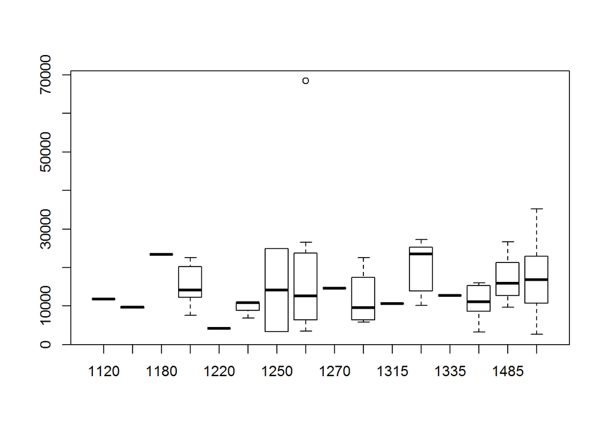

```r
library(ggplot2)
boxplot(water_consumption_cleaned$Water_Consumption~water_consumption_cleaned$Area_of_apt)
```

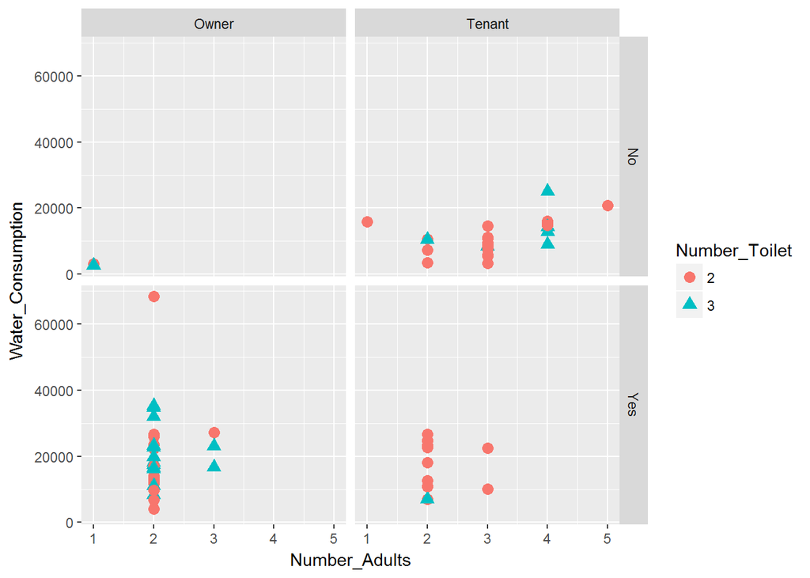

```r
# We can clearly make out an outlier for an apartment for area 1255

qplot(Number_Adults, Water_Consumption, data=water_consumption_cleaned, shape=Number_Toilet, color=Number_Toilet,
   facets=Family_Status~Resident_status, size=I(3),
   xlab="Number_Adults", ylab="Water_Consumption")
```